# Survival After Myocardial Infarction: A Reproducible Re-Analysis

How an inverted event indicator manufactured significant findings

Tyler Tschanz

May 2026

## Summary

This project re-analyses the public UCI Echocardiogram cohort (130 patients followed after myocardial infarction) using time-to-event methods. Its purpose is methodological. A prior version of this analysis defined the survival event as *being alive* rather than *death*, an inverted indicator that fabricated strong, statistically significant associations. With the event coded correctly, **those associations disappear**: no echocardiographic variable significantly predicts survival in this small cohort. The value here is the demonstration of correct survival methodology and the discipline to report a null result rather than a convenient one.

## The methodological error

In this dataset the status field `still_alive` is `1` when the patient was alive at last contact (a **right-censored** observation) and `0` when the patient **died** (the event of interest). The survival object must therefore be built with the event equal to `still_alive == 0`.

The prior analysis used:

```r
Surv(time = survival, event = still_alive)   # WRONG: alive coded as the event
```

This treats survivors as having experienced the event and decedents as censored. The resulting Kaplan-Meier curves, log-rank tests, and Cox model all estimate the hazard of *remaining alive*, which is not a meaningful quantity. Because the scrambled event/censoring structure remained correlated with the covariates, the broken model still produced small p-values, which were then interpreted as clinical findings. The correct specification is:

```r
Surv(time = survival_months, event = (still_alive == 0))
```

Every result below uses the correct specification.

## Data and provenance

The UCI Echocardiogram dataset records survival time, vital status, and echocardiographic measurements for patients after a heart attack. It is public, de-identified, and distributed under CC BY 4.0 (DOI 10.24432/C5QW24); the `name` field is a constant placeholder. Four source columns are excluded from analysis: the raw wall-motion score (superseded by the index), an undocumented derivative field (`mult`), the documented-meaningless `group` field, and `alive_at_1yr`. The last is a **post-outcome derived label**: it is determined by survival time and status at 12 months, so using it to predict survival would be target leakage.

The source file contains one structurally malformed record (line 50: a spurious leading comma yields 14 fields instead of 13). A lenient `read.csv` would silently wrap that line across two rows and corrupt the values, the same class of quiet data defect this project exists to expose. Ingestion therefore validates the field count of every line and **excludes** the malformed record explicitly rather than guessing at it.

Cohort derivation, from raw source file to model.

| Step | n |
| --- | --- |
| Source records | 132 |
| Excluded: malformed (line 50) | 1 |
| Well-formed records | 131 |
| Removed: missing or invalid time/status | 1 |
| Analysis cohort (Kaplan-Meier, log-rank) | 130 |
| Removed: missing model covariate | 23 |
| Complete-case cohort (Cox model) | 107 |

## Cohort

Cohort and censoring summary.

| Measure | Value |
| --- | --- |
| Patients | 130 |
| Deaths (events) | 88 (67.7%) |
| Censored (alive) | 42 |
| Median survival (Kaplan-Meier) | 29 months |
| Median follow-up | not reached (max 57 months) |
| Age at infarction, mean (SD) | 62.8 (8.4) |

This is a high-mortality cohort: 88 of 130 patients (68%) died during follow-up. Median follow-up is reported by the reverse Kaplan-Meier estimator, the correct estimator for follow-up time; it is not reached because fewer than half the patients are censored.

## Kaplan-Meier analysis

### By pericardial effusion

n = 130 (88 deaths, 42 censored; 0 excluded for a missing grouping value).

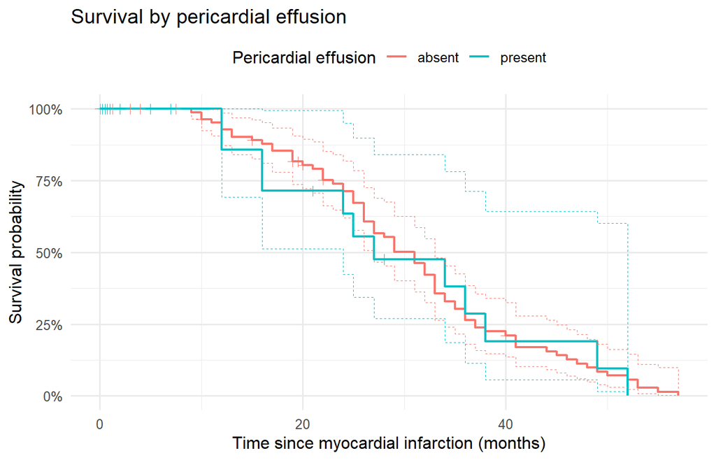

Number at risk.

| stratum | 0 | 12 | 24 | 36 | 48 |
| --- | --- | --- | --- | --- | --- |
| absent | 106 | 78 | 56 | 23 | 8 |
| present | 24 | 14 | 9 | 4 | 2 |

The curves overlap and there is no statistically significant difference (log-rank χ² = 0.02, p = 0.890).

### By wall-motion index

A pre-specified, clinically interpretable split is used for display only: an index of 1.0 means every visualised segment was normal, and a value above 1.0 indicates abnormal wall motion. The Cox model below keeps the index continuous and applies no cut-point.

n = 129 (88 deaths, 41 censored; 1 excluded for a missing grouping value).

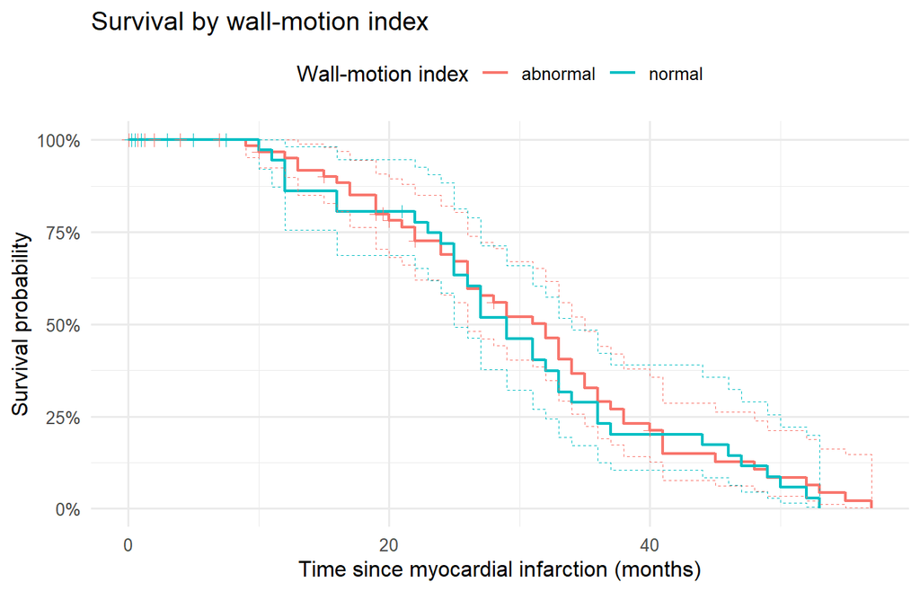

Number at risk.

| stratum | 0 | 12 | 24 | 36 | 48 |
| --- | --- | --- | --- | --- | --- |
| normal | 42 | 34 | 26 | 10 | 4 |
| abnormal | 87 | 58 | 39 | 17 | 6 |

Again there is no statistically significant difference (log-rank χ² = 0.34, p = 0.559).

## Cox proportional-hazards model

A multivariable Cox model was fitted on the 107 complete cases (75 deaths) with age, pericardial effusion, fractional shortening, E-point septal separation, left ventricular diastolic dimension, and the continuous wall-motion index.

Multivariable Cox hazard ratios.

|  | Term | Hazard ratio (95% CI) | p |
| --- | --- | --- | --- |
| age_at_mi | age_at_mi | 0.99 (0.96-1.02) | 0.486 |
| pericardial_effusionpresent | pericardial_effusionpresent | 0.99 (0.51-1.93) | 0.985 |
| fractional_shortening | fractional_shortening | 0.58 (0.05-6.75) | 0.666 |
| epss | epss | 1.02 (0.97-1.08) | 0.408 |
| lvdd | lvdd | 0.91 (0.64-1.29) | 0.603 |
| wall_motion_index | wall_motion_index | 0.83 (0.40-1.71) | 0.607 |

No covariate reaches significance. The model’s discrimination is effectively chance (Harrell’s C = 0.533) and it does not improve on the null model (likelihood-ratio test p = 0.930). The wide confidence intervals are consistent with a small sample and few events per variable.

### Proportional-hazards assumption

Scaled Schoenfeld residual test (cox.zph).

| Term | chisq | df | p |
| --- | --- | --- | --- |
| age_at_mi | 0.31 | 1 | 0.575 |
| pericardial_effusion | 0.05 | 1 | 0.828 |
| fractional_shortening | 0.37 | 1 | 0.544 |
| epss | 0.25 | 1 | 0.620 |
| lvdd | 0.10 | 1 | 0.754 |
| wall_motion_index | 1.48 | 1 | 0.223 |
| GLOBAL | 3.58 | 6 | 0.733 |

The global test (p = 0.733) and every per-term test are non-significant, so there is **no evidence of a proportional-hazards violation** (which is not the same as proving the assumption holds). It is also largely moot here: there is no effect to model.

## Interpretation

With the event indicator corrected, the previously reported “significant predictors of survival” vanish entirely. The honest conclusion is the absence of a finding: in this small, single-source cohort there is **no statistically significant evidence** that these echocardiographic measurements stratify post-infarction survival, and the multivariable Cox model shows no discriminative ability. This is *absence of evidence*, not evidence of absence: the cohort is small and underpowered, so a true moderate effect could easily go undetected. What can be said firmly is the negative methodological result, that the earlier significant findings were artifacts of the inverted event coding rather than clinical signal.

This is the intended result. The objective was not to find predictors; it was to apply survival methodology correctly and report what the data actually support.

## Limitations

- **Time origin and predictor timing.** The time scale is months since myocardial infarction, but the dataset does not document *when* each echocardiogram was performed relative to the infarction. If imaging occurred at variable, post-infarction times, patients had to survive to be measured, which introduces survivor / immortal-time bias. These results must therefore be read as a descriptive, retrospective association exercise, **not** as causal or prospective clinical prediction.
- Small cohort (130 patients; 107 complete cases) with few events per covariate, so confidence intervals are wide and the study is underpowered for modest effects (absence of evidence, not evidence of absence).
- Single-source observational data with documented quality issues (one malformed source record, placeholder/meaningless columns, missing values).
- The wall-motion dichotomy is for visualisation only and is not used for inference.
- No external validation cohort; findings describe this dataset only.

## Reproducibility

The analysis logic lives in `R/echo_survival.R`. Both the command-line runner (`R/run_analysis.R`) and this report source that single file, so the script and the report cannot disagree. `tests/test_pipeline.R` asserts the correct event coding and the expected row counts at every filtering step, so a regression in either fails loudly. Re-run end to end with:

```bash
Rscript R/run_analysis.R          # console summary + figures
Rscript tests/test_pipeline.R     # assertions (non-zero exit on failure)
Rscript -e 'rmarkdown::render("report/survival_analysis.Rmd")'
```

## References

Salzberg, S. (1988). *Echocardiogram* [Data set]. UCI Machine Learning Repository. CC BY 4.0. DOI 10.24432/C5QW24. https://archive.ics.uci.edu/dataset/38/echocardiogram

Therneau, T. (2024). *A Package for Survival Analysis in R*. R package version 3.x. https://CRAN.R-project.org/package=survival